# Risk Factor Analysis

## Outcome Variable

**Outcome Variable:** ever_stunted

## Predictor Variables

**Intervention Variable:** mage

**Adjustment Set:**

unadjusted

## Stratifying Variables

The analysis was stratified on these variable(s):

- agecat
- studyid
- country

## Data Summary

| agecat | studyid | country | mage | ever_stunted | n_cell | n |
| --- | --- | --- | --- | --- | --- | --- |
| 0-6 months | ki0047075b-MAL-ED | BANGLADESH | <20 | 0 | 28 | 265 |
| 0-6 months | ki0047075b-MAL-ED | BANGLADESH | <20 | 1 | 9 | 265 |
| 0-6 months | ki0047075b-MAL-ED | BANGLADESH | [20-25) | 0 | 74 | 265 |
| 0-6 months | ki0047075b-MAL-ED | BANGLADESH | [20-25) | 1 | 15 | 265 |
| 0-6 months | ki0047075b-MAL-ED | BANGLADESH | [25-30) | 0 | 78 | 265 |
| 0-6 months | ki0047075b-MAL-ED | BANGLADESH | [25-30) | 1 | 15 | 265 |
| 0-6 months | ki0047075b-MAL-ED | BANGLADESH | >=30 | 0 | 37 | 265 |
| 0-6 months | ki0047075b-MAL-ED | BANGLADESH | >=30 | 1 | 9 | 265 |
| 0-6 months | ki0047075b-MAL-ED | BRAZIL | <20 | 0 | 41 | 233 |
| 0-6 months | ki0047075b-MAL-ED | BRAZIL | <20 | 1 | 2 | 233 |
| 0-6 months | ki0047075b-MAL-ED | BRAZIL | [20-25) | 0 | 65 | 233 |
| 0-6 months | ki0047075b-MAL-ED | BRAZIL | [20-25) | 1 | 9 | 233 |
| 0-6 months | ki0047075b-MAL-ED | BRAZIL | [25-30) | 0 | 55 | 233 |
| 0-6 months | ki0047075b-MAL-ED | BRAZIL | [25-30) | 1 | 10 | 233 |
| 0-6 months | ki0047075b-MAL-ED | BRAZIL | >=30 | 0 | 47 | 233 |
| 0-6 months | ki0047075b-MAL-ED | BRAZIL | >=30 | 1 | 4 | 233 |
| 0-6 months | ki0047075b-MAL-ED | INDIA | <20 | 0 | 26 | 249 |
| 0-6 months | ki0047075b-MAL-ED | INDIA | <20 | 1 | 8 | 249 |
| 0-6 months | ki0047075b-MAL-ED | INDIA | [20-25) | 0 | 92 | 249 |
| 0-6 months | ki0047075b-MAL-ED | INDIA | [20-25) | 1 | 19 | 249 |
| 0-6 months | ki0047075b-MAL-ED | INDIA | [25-30) | 0 | 70 | 249 |
| 0-6 months | ki0047075b-MAL-ED | INDIA | [25-30) | 1 | 13 | 249 |
| 0-6 months | ki0047075b-MAL-ED | INDIA | >=30 | 0 | 20 | 249 |
| 0-6 months | ki0047075b-MAL-ED | INDIA | >=30 | 1 | 1 | 249 |
| 0-6 months | ki0047075b-MAL-ED | NEPAL | <20 | 0 | 3 | 240 |
| 0-6 months | ki0047075b-MAL-ED | NEPAL | <20 | 1 | 2 | 240 |
| 0-6 months | ki0047075b-MAL-ED | NEPAL | [20-25) | 0 | 51 | 240 |
| 0-6 months | ki0047075b-MAL-ED | NEPAL | [20-25) | 1 | 10 | 240 |
| 0-6 months | ki0047075b-MAL-ED | NEPAL | [25-30) | 0 | 116 | 240 |
| 0-6 months | ki0047075b-MAL-ED | NEPAL | [25-30) | 1 | 12 | 240 |

[output cut: 604 more lines]

The following strata were considered:

- agecat: 0-24 months, studyid: ki0047075b-MAL-ED, country: BANGLADESH
- agecat: 0-24 months, studyid: ki0047075b-MAL-ED, country: BRAZIL
- agecat: 0-24 months, studyid: ki0047075b-MAL-ED, country: INDIA
- agecat: 0-24 months, studyid: ki0047075b-MAL-ED, country: NEPAL
- agecat: 0-24 months, studyid: ki0047075b-MAL-ED, country: PERU
- agecat: 0-24 months, studyid: ki0047075b-MAL-ED, country: SOUTH AFRICA
- agecat: 0-24 months, studyid: ki0047075b-MAL-ED, country: TANZANIA, UNITED REPUBLIC OF
- agecat: 0-24 months, studyid: ki1000108-CMC-V-BCS-2002, country: INDIA
- agecat: 0-24 months, studyid: ki1000108-IRC, country: INDIA
- agecat: 0-24 months, studyid: ki1000109-EE, country: PAKISTAN
- agecat: 0-24 months, studyid: ki1000304b-SAS-CompFeed, country: INDIA
- agecat: 0-24 months, studyid: ki1000304b-SAS-FoodSuppl, country: INDIA
- agecat: 0-24 months, studyid: ki1017093-NIH-Birth, country: BANGLADESH
- agecat: 0-24 months, studyid: ki1017093b-PROVIDE, country: BANGLADESH
- agecat: 0-24 months, studyid: ki1017093c-NIH-Crypto, country: BANGLADESH
- agecat: 0-24 months, studyid: ki1066203-TanzaniaChild2, country: TANZANIA, UNITED REPUBLIC OF
- agecat: 0-24 months, studyid: ki1101329-Keneba, country: GAMBIA
- agecat: 0-24 months, studyid: ki1112895-Guatemala BSC, country: GUATEMALA
- agecat: 0-24 months, studyid: ki1112895-iLiNS-Zinc, country: BURKINA FASO
- agecat: 0-24 months, studyid: ki1113344-GMS-Nepal, country: NEPAL
- agecat: 0-24 months, studyid: ki1119695-PROBIT, country: BELARUS
- agecat: 0-24 months, studyid: ki1126311-ZVITAMBO, country: ZIMBABWE
- agecat: 0-24 months, studyid: ki1135781-COHORTS, country: GUATEMALA
- agecat: 0-24 months, studyid: ki1135781-COHORTS, country: INDIA
- agecat: 0-24 months, studyid: ki1135781-COHORTS, country: PHILIPPINES
- agecat: 0-24 months, studyid: ki1148112-LCNI-5, country: MALAWI
- agecat: 0-24 months, studyid: kiGH5241-JiVitA-3, country: BANGLADESH
- agecat: 0-6 months, studyid: ki0047075b-MAL-ED, country: BANGLADESH
- agecat: 0-6 months, studyid: ki0047075b-MAL-ED, country: BRAZIL
- agecat: 0-6 months, studyid: ki0047075b-MAL-ED, country: INDIA
- agecat: 0-6 months, studyid: ki0047075b-MAL-ED, country: NEPAL
- agecat: 0-6 months, studyid: ki0047075b-MAL-ED, country: PERU
- agecat: 0-6 months, studyid: ki0047075b-MAL-ED, country: SOUTH AFRICA
- agecat: 0-6 months, studyid: ki0047075b-MAL-ED, country: TANZANIA, UNITED REPUBLIC OF
- agecat: 0-6 months, studyid: ki1000108-CMC-V-BCS-2002, country: INDIA
- agecat: 0-6 months, studyid: ki1000108-IRC, country: INDIA
- agecat: 0-6 months, studyid: ki1000109-EE, country: PAKISTAN
- agecat: 0-6 months, studyid: ki1000304b-SAS-CompFeed, country: INDIA
- agecat: 0-6 months, studyid: ki1000304b-SAS-FoodSuppl, country: INDIA
- agecat: 0-6 months, studyid: ki1017093-NIH-Birth, country: BANGLADESH
- agecat: 0-6 months, studyid: ki1017093b-PROVIDE, country: BANGLADESH
- agecat: 0-6 months, studyid: ki1017093c-NIH-Crypto, country: BANGLADESH
- agecat: 0-6 months, studyid: ki1066203-TanzaniaChild2, country: TANZANIA, UNITED REPUBLIC OF
- agecat: 0-6 months, studyid: ki1101329-Keneba, country: GAMBIA
- agecat: 0-6 months, studyid: ki1112895-Guatemala BSC, country: GUATEMALA
- agecat: 0-6 months, studyid: ki1113344-GMS-Nepal, country: NEPAL
- agecat: 0-6 months, studyid: ki1119695-PROBIT, country: BELARUS
- agecat: 0-6 months, studyid: ki1126311-ZVITAMBO, country: ZIMBABWE
- agecat: 0-6 months, studyid: ki1135781-COHORTS, country: GUATEMALA
- agecat: 0-6 months, studyid: ki1135781-COHORTS, country: INDIA
- agecat: 0-6 months, studyid: ki1135781-COHORTS, country: PHILIPPINES
- agecat: 0-6 months, studyid: ki1148112-LCNI-5, country: MALAWI
- agecat: 0-6 months, studyid: kiGH5241-JiVitA-3, country: BANGLADESH
- agecat: 6-24 months, studyid: ki0047075b-MAL-ED, country: BANGLADESH
- agecat: 6-24 months, studyid: ki0047075b-MAL-ED, country: BRAZIL
- agecat: 6-24 months, studyid: ki0047075b-MAL-ED, country: INDIA
- agecat: 6-24 months, studyid: ki0047075b-MAL-ED, country: NEPAL
- agecat: 6-24 months, studyid: ki0047075b-MAL-ED, country: PERU
- agecat: 6-24 months, studyid: ki0047075b-MAL-ED, country: SOUTH AFRICA
- agecat: 6-24 months, studyid: ki0047075b-MAL-ED, country: TANZANIA, UNITED REPUBLIC OF
- agecat: 6-24 months, studyid: ki1000108-CMC-V-BCS-2002, country: INDIA
- agecat: 6-24 months, studyid: ki1000108-IRC, country: INDIA
- agecat: 6-24 months, studyid: ki1000109-EE, country: PAKISTAN
- agecat: 6-24 months, studyid: ki1000304b-SAS-CompFeed, country: INDIA
- agecat: 6-24 months, studyid: ki1000304b-SAS-FoodSuppl, country: INDIA
- agecat: 6-24 months, studyid: ki1017093-NIH-Birth, country: BANGLADESH
- agecat: 6-24 months, studyid: ki1017093b-PROVIDE, country: BANGLADESH
- agecat: 6-24 months, studyid: ki1017093c-NIH-Crypto, country: BANGLADESH
- agecat: 6-24 months, studyid: ki1066203-TanzaniaChild2, country: TANZANIA, UNITED REPUBLIC OF
- agecat: 6-24 months, studyid: ki1101329-Keneba, country: GAMBIA
- agecat: 6-24 months, studyid: ki1112895-Guatemala BSC, country: GUATEMALA
- agecat: 6-24 months, studyid: ki1112895-iLiNS-Zinc, country: BURKINA FASO
- agecat: 6-24 months, studyid: ki1113344-GMS-Nepal, country: NEPAL
- agecat: 6-24 months, studyid: ki1119695-PROBIT, country: BELARUS
- agecat: 6-24 months, studyid: ki1126311-ZVITAMBO, country: ZIMBABWE
- agecat: 6-24 months, studyid: ki1135781-COHORTS, country: GUATEMALA
- agecat: 6-24 months, studyid: ki1135781-COHORTS, country: INDIA
- agecat: 6-24 months, studyid: ki1135781-COHORTS, country: PHILIPPINES
- agecat: 6-24 months, studyid: ki1148112-LCNI-5, country: MALAWI
- agecat: 6-24 months, studyid: kiGH5241-JiVitA-3, country: BANGLADESH

## Methods Detail

We’re interested in the causal parameters $E[Y_a]$ for all values of $a \in \mathcal{A}$. These parameters represent the mean outcome if, possibly contrary to fact, we intervened to set all units to have $A=a$. Under the randomization and positivity assumptions, these are identified by the statistical parameters $\psi_a=E_W[E_{Y|A,W}(Y|A=a,W)]$. In addition, we’re interested in the mean of $Y$, $E[Y]$ under no intervention (the observed mean). We will estimate these parameters by using SuperLearner to fit the relevant likelihood factors – $E_{Y|A,W}(Y|A=a,W)$ and $p(A=a|W)$, and then updating our likelihood fit using a joint TMLE.

For unadjusted analyses ($W=\{\}$), initial likelihoods were estimated using Lrnr_glm to estimate the simple $E(Y|A)$ and Lrnr_mean to estimate $p(A)$. For adjusted analyses, a small library containing Lrnr_glmnet, Lrnr_xgboost, and Lrnr_mean was used.

Having estimated these parameters, we will then use the delta method to estimate relative risks and attributable risks relative to a prespecified baseline level of $A$.

[output not shown]

# Results Detail

## Results Plots

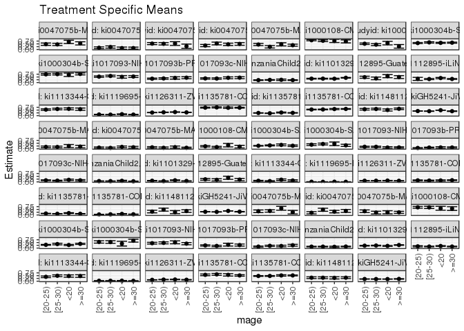

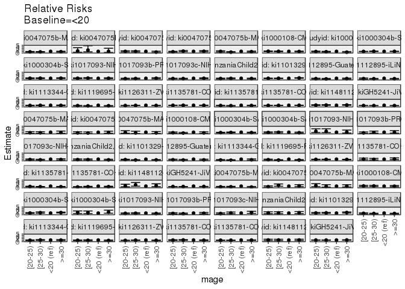

[figure not shown]

[figure not shown]

## Results Table

### Parameter: TSM

| agecat | studyid | country | intervention_level | baseline_level | estimate | ci_lower | ci_upper |
| --- | --- | --- | --- | --- | --- | --- | --- |
| 0-24 months | ki0047075b-MAL-ED | BANGLADESH | <20 | NA | 0.6756757 | 0.5245539 | 0.8267975 |
| 0-24 months | ki0047075b-MAL-ED | BANGLADESH | [20-25) | NA | 0.4719101 | 0.3680000 | 0.5758202 |
| 0-24 months | ki0047075b-MAL-ED | BANGLADESH | [25-30) | NA | 0.4516129 | 0.3502791 | 0.5529467 |
| 0-24 months | ki0047075b-MAL-ED | BANGLADESH | >=30 | NA | 0.5434783 | 0.3992628 | 0.6876938 |
| 0-24 months | ki0047075b-MAL-ED | BRAZIL | <20 | NA | 0.1162791 | 0.0202603 | 0.2122978 |
| 0-24 months | ki0047075b-MAL-ED | BRAZIL | [20-25) | NA | 0.1486486 | 0.0674215 | 0.2298758 |
| 0-24 months | ki0047075b-MAL-ED | BRAZIL | [25-30) | NA | 0.2153846 | 0.1152323 | 0.3155370 |
| 0-24 months | ki0047075b-MAL-ED | BRAZIL | >=30 | NA | 0.1176471 | 0.0290318 | 0.2062624 |
| 0-24 months | ki0047075b-MAL-ED | INDIA | <20 | NA | 0.5294118 | 0.3612993 | 0.6975242 |
| 0-24 months | ki0047075b-MAL-ED | INDIA | [20-25) | NA | 0.5225225 | 0.4294140 | 0.6156310 |
| 0-24 months | ki0047075b-MAL-ED | INDIA | [25-30) | NA | 0.5060241 | 0.3982483 | 0.6137999 |
| 0-24 months | ki0047075b-MAL-ED | INDIA | >=30 | NA | 0.2857143 | 0.0921103 | 0.4793182 |
| 0-24 months | ki0047075b-MAL-ED | PERU | <20 | NA | 0.4578313 | 0.3504703 | 0.5651924 |
| 0-24 months | ki0047075b-MAL-ED | PERU | [20-25) | NA | 0.3483146 | 0.2491685 | 0.4474607 |
| 0-24 months | ki0047075b-MAL-ED | PERU | [25-30) | NA | 0.5312500 | 0.4087895 | 0.6537105 |
| 0-24 months | ki0047075b-MAL-ED | PERU | >=30 | NA | 0.4925373 | 0.3726288 | 0.6124459 |
| 0-24 months | ki0047075b-MAL-ED | SOUTH AFRICA | <20 | NA | 0.4583333 | 0.3171521 | 0.5995145 |
| 0-24 months | ki0047075b-MAL-ED | SOUTH AFRICA | [20-25) | NA | 0.4411765 | 0.3446638 | 0.5376891 |
| 0-24 months | ki0047075b-MAL-ED | SOUTH AFRICA | [25-30) | NA | 0.2372881 | 0.1285622 | 0.3460140 |
| 0-24 months | ki0047075b-MAL-ED | SOUTH AFRICA | >=30 | NA | 0.3809524 | 0.2879180 | 0.4739868 |
| 0-24 months | ki1000108-CMC-V-BCS-2002 | INDIA | <20 | NA | 0.7647059 | 0.6219335 | 0.9074783 |
| 0-24 months | ki1000108-CMC-V-BCS-2002 | INDIA | [20-25) | NA | 0.8288770 | 0.7748253 | 0.8829287 |
| 0-24 months | ki1000108-CMC-V-BCS-2002 | INDIA | [25-30) | NA | 0.7798165 | 0.7019221 | 0.8577109 |
| 0-24 months | ki1000108-CMC-V-BCS-2002 | INDIA | >=30 | NA | 0.7209302 | 0.5866847 | 0.8551758 |
| 0-24 months | ki1000108-IRC | INDIA | <20 | NA | 0.5675676 | 0.4077423 | 0.7273928 |
| 0-24 months | ki1000108-IRC | INDIA | [20-25) | NA | 0.5113122 | 0.4453279 | 0.5772966 |
| 0-24 months | ki1000108-IRC | INDIA | [25-30) | NA | 0.4308943 | 0.3432734 | 0.5185152 |
| 0-24 months | ki1000108-IRC | INDIA | >=30 | NA | 0.2758621 | 0.1129940 | 0.4387302 |
| 0-24 months | ki1000304b-SAS-CompFeed | INDIA | <20 | NA | 0.5906736 | 0.5449278 | 0.6364194 |
| 0-24 months | ki1000304b-SAS-CompFeed | INDIA | [20-25) | NA | 0.5710456 | 0.5221961 | 0.6198951 |

[output cut: 222 more lines]

### Parameter: E(Y)

| agecat | studyid | country | intervention_level | baseline_level | estimate | ci_lower | ci_upper |
| --- | --- | --- | --- | --- | --- | --- | --- |
| 0-24 months | ki0047075b-MAL-ED | BANGLADESH | NA | NA | 0.5056604 | 0.4453505 | 0.5659702 |
| 0-24 months | ki0047075b-MAL-ED | BRAZIL | NA | NA | 0.1545064 | 0.1079979 | 0.2010150 |
| 0-24 months | ki0047075b-MAL-ED | INDIA | NA | NA | 0.4979920 | 0.4357636 | 0.5602204 |
| 0-24 months | ki0047075b-MAL-ED | PERU | NA | NA | 0.4488449 | 0.3927492 | 0.5049406 |
| 0-24 months | ki0047075b-MAL-ED | SOUTH AFRICA | NA | NA | 0.3853503 | 0.3314343 | 0.4392663 |
| 0-24 months | ki1000108-CMC-V-BCS-2002 | INDIA | NA | NA | 0.7962466 | 0.7553156 | 0.8371777 |
| 0-24 months | ki1000108-IRC | INDIA | NA | NA | 0.4756098 | 0.4272105 | 0.5240091 |
| 0-24 months | ki1000304b-SAS-CompFeed | INDIA | NA | NA | 0.5942596 | 0.5539147 | 0.6346046 |
| 0-24 months | ki1000304b-SAS-FoodSuppl | INDIA | NA | NA | 0.7464115 | 0.7046540 | 0.7881689 |
| 0-24 months | ki1017093-NIH-Birth | BANGLADESH | NA | NA | 0.5454545 | 0.5064488 | 0.5844603 |
| 0-24 months | ki1017093b-PROVIDE | BANGLADESH | NA | NA | 0.3757143 | 0.3398113 | 0.4116172 |
| 0-24 months | ki1017093c-NIH-Crypto | BANGLADESH | NA | NA | 0.3878628 | 0.3531521 | 0.4225735 |
| 0-24 months | ki1066203-TanzaniaChild2 | TANZANIA, UNITED REPUBLIC OF | NA | NA | 0.2251684 | 0.2083697 | 0.2419670 |
| 0-24 months | ki1101329-Keneba | GAMBIA | NA | NA | 0.3767051 | 0.3589402 | 0.3944701 |
| 0-24 months | ki1112895-Guatemala BSC | GUATEMALA | NA | NA | 0.4733096 | 0.4148280 | 0.5317912 |
| 0-24 months | ki1112895-iLiNS-Zinc | BURKINA FASO | NA | NA | 0.3314448 | 0.2804289 | 0.3824606 |
| 0-24 months | ki1113344-GMS-Nepal | NEPAL | NA | NA | 0.5780731 | 0.5385891 | 0.6175571 |
| 0-24 months | ki1119695-PROBIT | BELARUS | NA | NA | 0.1006096 | 0.0848963 | 0.1163228 |
| 0-24 months | ki1126311-ZVITAMBO | ZIMBABWE | NA | NA | 0.2924535 | 0.2849270 | 0.2999800 |
| 0-24 months | ki1135781-COHORTS | GUATEMALA | NA | NA | 0.7213235 | 0.6974864 | 0.7451606 |
| 0-24 months | ki1135781-COHORTS | INDIA | NA | NA | 0.2375306 | 0.2260863 | 0.2489749 |
| 0-24 months | ki1135781-COHORTS | PHILIPPINES | NA | NA | 0.5716154 | 0.5540738 | 0.5891570 |
| 0-24 months | ki1148112-LCNI-5 | MALAWI | NA | NA | 0.5820896 | 0.5447154 | 0.6194637 |
| 0-24 months | kiGH5241-JiVitA-3 | BANGLADESH | NA | NA | 0.4437098 | 0.4361997 | 0.4512200 |
| 0-6 months | ki0047075b-MAL-ED | BANGLADESH | NA | NA | 0.1811321 | 0.1346751 | 0.2275890 |
| 0-6 months | ki0047075b-MAL-ED | PERU | NA | NA | 0.1221122 | 0.0851852 | 0.1590392 |
| 0-6 months | ki0047075b-MAL-ED | SOUTH AFRICA | NA | NA | 0.1082803 | 0.0738560 | 0.1427045 |
| 0-6 months | ki1000108-CMC-V-BCS-2002 | INDIA | NA | NA | 0.2065217 | 0.1651060 | 0.2479375 |
| 0-6 months | ki1000304b-SAS-CompFeed | INDIA | NA | NA | 0.2882353 | 0.2618269 | 0.3146436 |
| 0-6 months | ki1000304b-SAS-FoodSuppl | INDIA | NA | NA | 0.3822115 | 0.3354600 | 0.4289631 |
| 0-6 months | ki1017093-NIH-Birth | BANGLADESH | NA | NA | 0.1578947 | 0.1293302 | 0.1864593 |
| 0-6 months | ki1017093b-PROVIDE | BANGLADESH | NA | NA | 0.0942857 | 0.0726222 | 0.1159492 |
| 0-6 months | ki1017093c-NIH-Crypto | BANGLADESH | NA | NA | 0.1385224 | 0.1139141 | 0.1631308 |
| 0-6 months | ki1066203-TanzaniaChild2 | TANZANIA, UNITED REPUBLIC OF | NA | NA | 0.0669192 | 0.0568695 | 0.0769688 |
| 0-6 months | ki1101329-Keneba | GAMBIA | NA | NA | 0.0929185 | 0.0814039 | 0.1044332 |
| 0-6 months | ki1112895-Guatemala BSC | GUATEMALA | NA | NA | 0.2386364 | 0.1871213 | 0.2901515 |
| 0-6 months | ki1113344-GMS-Nepal | NEPAL | NA | NA | 0.1112957 | 0.0861520 | 0.1364394 |
| 0-6 months | ki1119695-PROBIT | BELARUS | NA | NA | 0.0090570 | 0.0059070 | 0.0122070 |
| 0-6 months | ki1126311-ZVITAMBO | ZIMBABWE | NA | NA | 0.1051317 | 0.1000527 | 0.1102107 |
| 0-6 months | ki1135781-COHORTS | GUATEMALA | NA | NA | 0.1347388 | 0.1144687 | 0.1550088 |
| 0-6 months | ki1135781-COHORTS | INDIA | NA | NA | 0.1217137 | 0.1127702 | 0.1306572 |
| 0-6 months | ki1135781-COHORTS | PHILIPPINES | NA | NA | 0.0614781 | 0.0529631 | 0.0699931 |
| 0-6 months | ki1148112-LCNI-5 | MALAWI | NA | NA | 0.3545455 | 0.2911884 | 0.4179025 |
| 0-6 months | kiGH5241-JiVitA-3 | BANGLADESH | NA | NA | 0.3218454 | 0.3150991 | 0.3285918 |
| 6-24 months | ki0047075b-MAL-ED | BANGLADESH | NA | NA | 0.3743590 | 0.3062579 | 0.4424600 |
| 6-24 months | ki0047075b-MAL-ED | PERU | NA | NA | 0.3275109 | 0.2665942 | 0.3884276 |
| 6-24 months | ki0047075b-MAL-ED | SOUTH AFRICA | NA | NA | 0.2633929 | 0.2055812 | 0.3212045 |
| 6-24 months | ki1000108-CMC-V-BCS-2002 | INDIA | NA | NA | 0.6631944 | 0.6085159 | 0.7178730 |
| 6-24 months | ki1000304b-SAS-CompFeed | INDIA | NA | NA | 0.3184647 | 0.2882909 | 0.3486385 |
| 6-24 months | ki1000304b-SAS-FoodSuppl | INDIA | NA | NA | 0.5619469 | 0.4971181 | 0.6267757 |
| 6-24 months | ki1017093-NIH-Birth | BANGLADESH | NA | NA | 0.4510740 | 0.4033715 | 0.4987764 |
| 6-24 months | ki1017093b-PROVIDE | BANGLADESH | NA | NA | 0.2394366 | 0.2018814 | 0.2769918 |
| 6-24 months | ki1017093c-NIH-Crypto | BANGLADESH | NA | NA | 0.1887097 | 0.1578857 | 0.2195336 |
| 6-24 months | ki1066203-TanzaniaChild2 | TANZANIA, UNITED REPUBLIC OF | NA | NA | 0.1335878 | 0.1180133 | 0.1491622 |
| 6-24 months | ki1101329-Keneba | GAMBIA | NA | NA | 0.2387484 | 0.2214455 | 0.2560513 |
| 6-24 months | ki1112895-iLiNS-Zinc | BURKINA FASO | NA | NA | 0.1520334 | 0.1259980 | 0.1780689 |
| 6-24 months | ki1113344-GMS-Nepal | NEPAL | NA | NA | 0.4479167 | 0.4033837 | 0.4924496 |
| 6-24 months | ki1119695-PROBIT | BELARUS | NA | NA | 0.0380298 | 0.0285924 | 0.0474672 |
| 6-24 months | ki1126311-ZVITAMBO | ZIMBABWE | NA | NA | 0.1359725 | 0.1290044 | 0.1429405 |
| 6-24 months | ki1135781-COHORTS | GUATEMALA | NA | NA | 0.5625000 | 0.5235458 | 0.6014542 |
| 6-24 months | ki1135781-COHORTS | PHILIPPINES | NA | NA | 0.4901079 | 0.4693271 | 0.5108888 |
| 6-24 months | ki1148112-LCNI-5 | MALAWI | NA | NA | 0.3121019 | 0.2702120 | 0.3539918 |
| 6-24 months | kiGH5241-JiVitA-3 | BANGLADESH | NA | NA | 0.1970825 | 0.1890251 | 0.2051399 |

### Parameter: RR

| agecat | studyid | country | intervention_level | baseline_level | estimate | ci_lower | ci_upper |
| --- | --- | --- | --- | --- | --- | --- | --- |
| 0-24 months | ki0047075b-MAL-ED | BANGLADESH | <20 | <20 | 1.0000000 | 1.0000000 | 1.0000000 |
| 0-24 months | ki0047075b-MAL-ED | BANGLADESH | [20-25) | <20 | 0.6984270 | 0.5102859 | 0.9559351 |
| 0-24 months | ki0047075b-MAL-ED | BANGLADESH | [25-30) | <20 | 0.6683871 | 0.4868974 | 0.9175267 |
| 0-24 months | ki0047075b-MAL-ED | BANGLADESH | >=30 | <20 | 0.8043478 | 0.5684936 | 1.1380523 |
| 0-24 months | ki0047075b-MAL-ED | BRAZIL | <20 | <20 | 1.0000000 | 1.0000000 | 1.0000000 |
| 0-24 months | ki0047075b-MAL-ED | BRAZIL | [20-25) | <20 | 1.2783784 | 0.4749255 | 3.4410684 |
| 0-24 months | ki0047075b-MAL-ED | BRAZIL | [25-30) | <20 | 1.8523077 | 0.7180261 | 4.7784391 |
| 0-24 months | ki0047075b-MAL-ED | BRAZIL | >=30 | <20 | 1.0117647 | 0.3308809 | 3.0937655 |
| 0-24 months | ki0047075b-MAL-ED | INDIA | <20 | <20 | 1.0000000 | 1.0000000 | 1.0000000 |
| 0-24 months | ki0047075b-MAL-ED | INDIA | [20-25) | <20 | 0.9869870 | 0.6857628 | 1.4205252 |
| 0-24 months | ki0047075b-MAL-ED | INDIA | [25-30) | <20 | 0.9558233 | 0.6521108 | 1.4009862 |
| 0-24 months | ki0047075b-MAL-ED | INDIA | >=30 | <20 | 0.5396825 | 0.2553544 | 1.1406000 |
| 0-24 months | ki0047075b-MAL-ED | PERU | <20 | <20 | 1.0000000 | 1.0000000 | 1.0000000 |
| 0-24 months | ki0047075b-MAL-ED | PERU | [20-25) | <20 | 0.7607924 | 0.5261369 | 1.1001037 |
| 0-24 months | ki0047075b-MAL-ED | PERU | [25-30) | <20 | 1.1603618 | 0.8351916 | 1.6121326 |
| 0-24 months | ki0047075b-MAL-ED | PERU | >=30 | <20 | 1.0758052 | 0.7672432 | 1.5084615 |
| 0-24 months | ki0047075b-MAL-ED | SOUTH AFRICA | <20 | <20 | 1.0000000 | 1.0000000 | 1.0000000 |
| 0-24 months | ki0047075b-MAL-ED | SOUTH AFRICA | [20-25) | <20 | 0.9625668 | 0.6597055 | 1.4044674 |
| 0-24 months | ki0047075b-MAL-ED | SOUTH AFRICA | [25-30) | <20 | 0.5177196 | 0.2980667 | 0.8992402 |
| 0-24 months | ki0047075b-MAL-ED | SOUTH AFRICA | >=30 | <20 | 0.8311688 | 0.5610089 | 1.2314273 |
| 0-24 months | ki1000108-CMC-V-BCS-2002 | INDIA | <20 | <20 | 1.0000000 | 1.0000000 | 1.0000000 |
| 0-24 months | ki1000108-CMC-V-BCS-2002 | INDIA | [20-25) | <20 | 1.0839161 | 0.8894228 | 1.3209399 |
| 0-24 months | ki1000108-CMC-V-BCS-2002 | INDIA | [25-30) | <20 | 1.0197601 | 0.8251613 | 1.2602513 |
| 0-24 months | ki1000108-CMC-V-BCS-2002 | INDIA | >=30 | <20 | 0.9427549 | 0.7242352 | 1.2272075 |
| 0-24 months | ki1000108-IRC | INDIA | <20 | <20 | 1.0000000 | 1.0000000 | 1.0000000 |
| 0-24 months | ki1000108-IRC | INDIA | [20-25) | <20 | 0.9008834 | 0.6609097 | 1.2279908 |
| 0-24 months | ki1000108-IRC | INDIA | [25-30) | <20 | 0.7591947 | 0.5364193 | 1.0744891 |
| 0-24 months | ki1000108-IRC | INDIA | >=30 | <20 | 0.4860427 | 0.2526948 | 0.9348729 |
| 0-24 months | ki1000304b-SAS-CompFeed | INDIA | <20 | <20 | 1.0000000 | 1.0000000 | 1.0000000 |
| 0-24 months | ki1000304b-SAS-CompFeed | INDIA | [20-25) | <20 | 0.9667701 | 0.8639884 | 1.0817790 |

[output cut: 222 more lines]

### Parameter: PAR

| agecat | studyid | country | intervention_level | baseline_level | estimate | ci_lower | ci_upper |
| --- | --- | --- | --- | --- | --- | --- | --- |
| 0-24 months | ki0047075b-MAL-ED | BANGLADESH | <20 | NA | -0.1700153 | -0.3117818 | -0.0282488 |
| 0-24 months | ki0047075b-MAL-ED | BRAZIL | <20 | NA | 0.0382274 | -0.0511018 | 0.1275566 |
| 0-24 months | ki0047075b-MAL-ED | INDIA | <20 | NA | -0.0314198 | -0.1876763 | 0.1248367 |
| 0-24 months | ki0047075b-MAL-ED | PERU | <20 | NA | -0.0089864 | -0.1004104 | 0.0824375 |
| 0-24 months | ki0047075b-MAL-ED | SOUTH AFRICA | <20 | NA | -0.0729830 | -0.2023861 | 0.0564201 |
| 0-24 months | ki1000108-CMC-V-BCS-2002 | INDIA | <20 | NA | 0.0315408 | -0.1038963 | 0.1669778 |
| 0-24 months | ki1000108-IRC | INDIA | <20 | NA | -0.0919578 | -0.2445232 | 0.0606076 |
| 0-24 months | ki1000304b-SAS-CompFeed | INDIA | <20 | NA | 0.0035860 | -0.0548487 | 0.0620207 |
| 0-24 months | ki1000304b-SAS-FoodSuppl | INDIA | <20 | NA | 0.0519670 | -0.0913189 | 0.1952530 |
| 0-24 months | ki1017093-NIH-Birth | BANGLADESH | <20 | NA | 0.0386052 | -0.0692279 | 0.1464384 |
| 0-24 months | ki1017093b-PROVIDE | BANGLADESH | <20 | NA | -0.0360504 | -0.1339738 | 0.0618729 |
| 0-24 months | ki1017093c-NIH-Crypto | BANGLADESH | <20 | NA | -0.0386078 | -0.1137099 | 0.0364944 |
| 0-24 months | ki1066203-TanzaniaChild2 | TANZANIA, UNITED REPUBLIC OF | <20 | NA | -0.0203406 | -0.0831552 | 0.0424739 |
| 0-24 months | ki1101329-Keneba | GAMBIA | <20 | NA | 0.0349330 | -0.0086495 | 0.0785154 |
| 0-24 months | ki1112895-Guatemala BSC | GUATEMALA | <20 | NA | -0.1011585 | -0.2306340 | 0.0283171 |
| 0-24 months | ki1112895-iLiNS-Zinc | BURKINA FASO | <20 | NA | -0.0705404 | -0.1344898 | -0.0065909 |
| 0-24 months | ki1113344-GMS-Nepal | NEPAL | <20 | NA | -0.0316830 | -0.1088910 | 0.0455250 |
| 0-24 months | ki1119695-PROBIT | BELARUS | <20 | NA | -0.0294764 | -0.0487314 | -0.0102214 |
| 0-24 months | ki1126311-ZVITAMBO | ZIMBABWE | <20 | NA | -0.0313645 | -0.0490268 | -0.0137022 |
| 0-24 months | ki1135781-COHORTS | GUATEMALA | <20 | NA | 0.0134027 | -0.0443408 | 0.0711462 |
| 0-24 months | ki1135781-COHORTS | INDIA | <20 | NA | -0.0411579 | -0.0817663 | -0.0005496 |
| 0-24 months | ki1135781-COHORTS | PHILIPPINES | <20 | NA | -0.0209772 | -0.0674021 | 0.0254477 |
| 0-24 months | ki1148112-LCNI-5 | MALAWI | <20 | NA | 0.0728303 | -0.0133629 | 0.1590235 |
| 0-24 months | kiGH5241-JiVitA-3 | BANGLADESH | <20 | NA | -0.0445554 | -0.0514292 | -0.0376816 |
| 0-6 months | ki0047075b-MAL-ED | BANGLADESH | <20 | NA | -0.0621112 | -0.1885431 | 0.0643207 |
| 0-6 months | ki0047075b-MAL-ED | PERU | <20 | NA | -0.0465625 | -0.1121956 | 0.0190706 |
| 0-6 months | ki0047075b-MAL-ED | SOUTH AFRICA | <20 | NA | -0.0375531 | -0.1277104 | 0.0526042 |
| 0-6 months | ki1000108-CMC-V-BCS-2002 | INDIA | <20 | NA | -0.1170077 | -0.2650903 | 0.0310750 |
| 0-6 months | ki1000304b-SAS-CompFeed | INDIA | <20 | NA | -0.0589150 | -0.1415395 | 0.0237096 |
| 0-6 months | ki1000304b-SAS-FoodSuppl | INDIA | <20 | NA | -0.0622329 | -0.2172346 | 0.0927688 |
| 0-6 months | ki1017093-NIH-Birth | BANGLADESH | <20 | NA | 0.0483057 | -0.0206974 | 0.1173088 |
| 0-6 months | ki1017093b-PROVIDE | BANGLADESH | <20 | NA | -0.0233613 | -0.0868155 | 0.0400928 |
| 0-6 months | ki1017093c-NIH-Crypto | BANGLADESH | <20 | NA | -0.0453011 | -0.1029750 | 0.0123728 |
| 0-6 months | ki1066203-TanzaniaChild2 | TANZANIA, UNITED REPUBLIC OF | <20 | NA | -0.0288892 | -0.0714839 | 0.0137055 |
| 0-6 months | ki1101329-Keneba | GAMBIA | <20 | NA | -0.0491427 | -0.0816056 | -0.0166799 |
| 0-6 months | ki1112895-Guatemala BSC | GUATEMALA | <20 | NA | -0.1309289 | -0.2549383 | -0.0069194 |
| 0-6 months | ki1113344-GMS-Nepal | NEPAL | <20 | NA | -0.0838263 | -0.1433039 | -0.0243487 |
| 0-6 months | ki1119695-PROBIT | BELARUS | <20 | NA | -0.0058513 | -0.0118369 | 0.0001344 |
| 0-6 months | ki1126311-ZVITAMBO | ZIMBABWE | <20 | NA | -0.0124365 | -0.0245638 | -0.0003092 |
| 0-6 months | ki1135781-COHORTS | GUATEMALA | <20 | NA | 0.0072220 | -0.0427548 | 0.0571987 |
| 0-6 months | ki1135781-COHORTS | INDIA | <20 | NA | -0.0470208 | -0.0817678 | -0.0122737 |
| 0-6 months | ki1135781-COHORTS | PHILIPPINES | <20 | NA | -0.0337600 | -0.0608140 | -0.0067060 |
| 0-6 months | ki1148112-LCNI-5 | MALAWI | <20 | NA | 0.0981352 | -0.0291096 | 0.2253800 |
| 0-6 months | kiGH5241-JiVitA-3 | BANGLADESH | <20 | NA | -0.0437893 | -0.0502882 | -0.0372905 |
| 6-24 months | ki0047075b-MAL-ED | BANGLADESH | <20 | NA | -0.2256410 | -0.3869581 | -0.0643240 |
| 6-24 months | ki0047075b-MAL-ED | PERU | <20 | NA | 0.0244806 | -0.0700746 | 0.1190358 |
| 6-24 months | ki0047075b-MAL-ED | SOUTH AFRICA | <20 | NA | 0.0201496 | -0.1071193 | 0.1474185 |
| 6-24 months | ki1000108-CMC-V-BCS-2002 | INDIA | <20 | NA | 0.0631944 | -0.1023464 | 0.2287352 |
| 6-24 months | ki1000304b-SAS-CompFeed | INDIA | <20 | NA | 0.0384647 | -0.0242858 | 0.1012152 |
| 6-24 months | ki1000304b-SAS-FoodSuppl | INDIA | <20 | NA | 0.1619469 | -0.0437471 | 0.3676410 |
| 6-24 months | ki1017093-NIH-Birth | BANGLADESH | <20 | NA | -0.0667832 | -0.1886635 | 0.0550972 |
| 6-24 months | ki1017093b-PROVIDE | BANGLADESH | <20 | NA | -0.0682557 | -0.1860651 | 0.0495537 |
| 6-24 months | ki1017093c-NIH-Crypto | BANGLADESH | <20 | NA | -0.0004795 | -0.0665361 | 0.0655771 |
| 6-24 months | ki1066203-TanzaniaChild2 | TANZANIA, UNITED REPUBLIC OF | <20 | NA | 0.0173087 | -0.0362967 | 0.0709141 |
| 6-24 months | ki1101329-Keneba | GAMBIA | <20 | NA | 0.0418734 | 0.0009175 | 0.0828293 |
| 6-24 months | ki1112895-iLiNS-Zinc | BURKINA FASO | <20 | NA | -0.0364650 | -0.0692239 | -0.0037060 |
| 6-24 months | ki1113344-GMS-Nepal | NEPAL | <20 | NA | -0.0187500 | -0.1116833 | 0.0741833 |
| 6-24 months | ki1119695-PROBIT | BELARUS | <20 | NA | -0.0073704 | -0.0180381 | 0.0032972 |
| 6-24 months | ki1126311-ZVITAMBO | ZIMBABWE | <20 | NA | -0.0192851 | -0.0364822 | -0.0020881 |
| 6-24 months | ki1135781-COHORTS | GUATEMALA | <20 | NA | -0.0089286 | -0.1074927 | 0.0896355 |
| 6-24 months | ki1135781-COHORTS | PHILIPPINES | <20 | NA | -0.0285488 | -0.0846656 | 0.0275680 |
| 6-24 months | ki1148112-LCNI-5 | MALAWI | <20 | NA | 0.0108971 | -0.0789719 | 0.1007661 |
| 6-24 months | kiGH5241-JiVitA-3 | BANGLADESH | <20 | NA | 0.0024879 | -0.0054486 | 0.0104244 |

### Parameter: PAF

| agecat | studyid | country | intervention_level | baseline_level | estimate | ci_lower | ci_upper |
| --- | --- | --- | --- | --- | --- | --- | --- |
| 0-24 months | ki0047075b-MAL-ED | BANGLADESH | <20 | NA | -0.3362243 | -0.6542551 | -0.0793349 |
| 0-24 months | ki0047075b-MAL-ED | BRAZIL | <20 | NA | 0.2474160 | -0.6150303 | 0.6493053 |
| 0-24 months | ki0047075b-MAL-ED | INDIA | <20 | NA | -0.0630930 | -0.4282315 | 0.2086951 |
| 0-24 months | ki0047075b-MAL-ED | PERU | <20 | NA | -0.0200213 | -0.2454819 | 0.1646259 |
| 0-24 months | ki0047075b-MAL-ED | SOUTH AFRICA | <20 | NA | -0.1893939 | -0.5780810 | 0.1035581 |
| 0-24 months | ki1000108-CMC-V-BCS-2002 | INDIA | <20 | NA | 0.0396118 | -0.1465700 | 0.1955611 |
| 0-24 months | ki1000108-IRC | INDIA | <20 | NA | -0.1933472 | -0.5622954 | 0.0884710 |
| 0-24 months | ki1000304b-SAS-CompFeed | INDIA | <20 | NA | 0.0060345 | -0.0970435 | 0.0994273 |
| 0-24 months | ki1000304b-SAS-FoodSuppl | INDIA | <20 | NA | 0.0696225 | -0.1438010 | 0.2432230 |
| 0-24 months | ki1017093-NIH-Birth | BANGLADESH | <20 | NA | 0.0707763 | -0.1496206 | 0.2489202 |
| 0-24 months | ki1017093b-PROVIDE | BANGLADESH | <20 | NA | -0.0959517 | -0.3902505 | 0.1360477 |
| 0-24 months | ki1017093c-NIH-Crypto | BANGLADESH | <20 | NA | -0.0995398 | -0.3113624 | 0.0780674 |
| 0-24 months | ki1066203-TanzaniaChild2 | TANZANIA, UNITED REPUBLIC OF | <20 | NA | -0.0903352 | -0.4082000 | 0.1557798 |
| 0-24 months | ki1101329-Keneba | GAMBIA | <20 | NA | 0.0927330 | -0.0306703 | 0.2013611 |
| 0-24 months | ki1112895-Guatemala BSC | GUATEMALA | <20 | NA | -0.2137258 | -0.5224418 | 0.0323897 |
| 0-24 months | ki1112895-iLiNS-Zinc | BURKINA FASO | <20 | NA | -0.2128269 | -0.4451219 | -0.0178719 |
| 0-24 months | ki1113344-GMS-Nepal | NEPAL | <20 | NA | -0.0548080 | -0.1973057 | 0.0707304 |
| 0-24 months | ki1119695-PROBIT | BELARUS | <20 | NA | -0.2929779 | -0.4852965 | -0.1255611 |
| 0-24 months | ki1126311-ZVITAMBO | ZIMBABWE | <20 | NA | -0.1072462 | -0.1693114 | -0.0484753 |
| 0-24 months | ki1135781-COHORTS | GUATEMALA | <20 | NA | 0.0185808 | -0.0648373 | 0.0954639 |
| 0-24 months | ki1135781-COHORTS | INDIA | <20 | NA | -0.1732743 | -0.3572544 | -0.0142333 |
| 0-24 months | ki1135781-COHORTS | PHILIPPINES | <20 | NA | -0.0366980 | -0.1211960 | 0.0414319 |
| 0-24 months | ki1148112-LCNI-5 | MALAWI | <20 | NA | 0.1251187 | -0.0365964 | 0.2616053 |
| 0-24 months | kiGH5241-JiVitA-3 | BANGLADESH | <20 | NA | -0.1004156 | -0.1161898 | -0.0848643 |
| 0-6 months | ki0047075b-MAL-ED | BANGLADESH | <20 | NA | -0.3429054 | -1.2545122 | 0.2000953 |
| 0-6 months | ki0047075b-MAL-ED | PERU | <20 | NA | -0.3813090 | -1.0270650 | 0.0587304 |
| 0-6 months | ki0047075b-MAL-ED | SOUTH AFRICA | <20 | NA | -0.3468137 | -1.4900550 | 0.2715393 |
| 0-6 months | ki1000108-CMC-V-BCS-2002 | INDIA | <20 | NA | -0.5665635 | -1.4732492 | 0.0077340 |
| 0-6 months | ki1000304b-SAS-CompFeed | INDIA | <20 | NA | -0.2043989 | -0.5328846 | 0.0536948 |
| 0-6 months | ki1000304b-SAS-FoodSuppl | INDIA | <20 | NA | -0.1628232 | -0.6483737 | 0.1797019 |
| 0-6 months | ki1017093-NIH-Birth | BANGLADESH | <20 | NA | 0.3059361 | -0.2978590 | 0.6288312 |
| 0-6 months | ki1017093b-PROVIDE | BANGLADESH | <20 | NA | -0.2477718 | -1.1367579 | 0.2713566 |
| 0-6 months | ki1017093c-NIH-Crypto | BANGLADESH | <20 | NA | -0.3270308 | -0.8129120 | 0.0286287 |
| 0-6 months | ki1066203-TanzaniaChild2 | TANZANIA, UNITED REPUBLIC OF | <20 | NA | -0.4317026 | -1.2291265 | 0.0804594 |
| 0-6 months | ki1101329-Keneba | GAMBIA | <20 | NA | -0.5288798 | -0.9160579 | -0.2199388 |
| 0-6 months | ki1112895-Guatemala BSC | GUATEMALA | <20 | NA | -0.5486542 | -1.1655769 | -0.1074785 |
| 0-6 months | ki1113344-GMS-Nepal | NEPAL | <20 | NA | -0.7531853 | -1.3571743 | -0.3039590 |
| 0-6 months | ki1119695-PROBIT | BELARUS | <20 | NA | -0.6460469 | -1.3293377 | -0.1631935 |
| 0-6 months | ki1126311-ZVITAMBO | ZIMBABWE | <20 | NA | -0.1182944 | -0.2396916 | -0.0087850 |
| 0-6 months | ki1135781-COHORTS | GUATEMALA | <20 | NA | 0.0536000 | -0.4004137 | 0.3604226 |
| 0-6 months | ki1135781-COHORTS | INDIA | <20 | NA | -0.3863226 | -0.7022554 | -0.1290258 |
| 0-6 months | ki1135781-COHORTS | PHILIPPINES | <20 | NA | -0.5491388 | -1.0510755 | -0.1700354 |
| 0-6 months | ki1148112-LCNI-5 | MALAWI | <20 | NA | 0.2767916 | -0.1867606 | 0.5592789 |
| 0-6 months | kiGH5241-JiVitA-3 | BANGLADESH | <20 | NA | -0.1360571 | -0.1565422 | -0.1159347 |
| 6-24 months | ki0047075b-MAL-ED | BANGLADESH | <20 | NA | -0.6027397 | -1.1137239 | -0.2152839 |
| 6-24 months | ki0047075b-MAL-ED | PERU | <20 | NA | 0.0747475 | -0.2640336 | 0.3227299 |
| 6-24 months | ki0047075b-MAL-ED | SOUTH AFRICA | <20 | NA | 0.0765002 | -0.5581893 | 0.4526648 |
| 6-24 months | ki1000108-CMC-V-BCS-2002 | INDIA | <20 | NA | 0.0952880 | -0.1925725 | 0.3136653 |
| 6-24 months | ki1000304b-SAS-CompFeed | INDIA | <20 | NA | 0.1207818 | -0.0926528 | 0.2925249 |
| 6-24 months | ki1000304b-SAS-FoodSuppl | INDIA | <20 | NA | 0.2881890 | -0.1924881 | 0.5751111 |
| 6-24 months | ki1017093-NIH-Birth | BANGLADESH | <20 | NA | -0.1480537 | -0.4532076 | 0.0930221 |
| 6-24 months | ki1017093b-PROVIDE | BANGLADESH | <20 | NA | -0.2850679 | -0.8839866 | 0.1234548 |
| 6-24 months | ki1017093c-NIH-Crypto | BANGLADESH | <20 | NA | -0.0025410 | -0.4214732 | 0.2929248 |
| 6-24 months | ki1066203-TanzaniaChild2 | TANZANIA, UNITED REPUBLIC OF | <20 | NA | 0.1295681 | -0.3798871 | 0.4509321 |
| 6-24 months | ki1101329-Keneba | GAMBIA | <20 | NA | 0.1753871 | -0.0150247 | 0.3300789 |
| 6-24 months | ki1112895-iLiNS-Zinc | BURKINA FASO | <20 | NA | -0.2398482 | -0.4835322 | -0.0361917 |
| 6-24 months | ki1113344-GMS-Nepal | NEPAL | <20 | NA | -0.0418605 | -0.2714761 | 0.1462889 |
| 6-24 months | ki1119695-PROBIT | BELARUS | <20 | NA | -0.1938066 | -0.4996371 | 0.0496540 |
| 6-24 months | ki1126311-ZVITAMBO | ZIMBABWE | <20 | NA | -0.1418311 | -0.2754264 | -0.0222293 |
| 6-24 months | ki1135781-COHORTS | GUATEMALA | <20 | NA | -0.0158730 | -0.2071244 | 0.1450774 |
| 6-24 months | ki1135781-COHORTS | PHILIPPINES | <20 | NA | -0.0582500 | -0.1792033 | 0.0502968 |
| 6-24 months | ki1148112-LCNI-5 | MALAWI | <20 | NA | 0.0349152 | -0.3005937 | 0.2838742 |
| 6-24 months | kiGH5241-JiVitA-3 | BANGLADESH | <20 | NA | 0.0126236 | -0.0284312 | 0.0520396 |